# pertemuan-11-PDS (1)

### 1. Data dan Preview Data

Dataset mpg berisi informasi mengenai karakteristik mobil, termasuk konsumsi bahan bakar (mpg) dan tenaga mesin (horsepower). Data dibersihkan terlebih dahulu dari nilai kosong (missing values) agar siap digunakan untuk analisis lebih lanjut. Di sini saya memilih bahan bakar (mpg) sebagai variabel dependen (Y) dan tenaga mesin (horsepower) sebagai variabel independen (X).

```python
import pandas as pd
import numpy as np
import seaborn as sns
import matplotlib.pyplot as plt
import statsmodels.api as sm
from statsmodels.stats.diagnostic import het_breuschpagan
from statsmodels.stats.outliers_influence import variance_inflation_factor
from statsmodels.stats.stattools import durbin_watson
from scipy import stats


df = sns.load_dataset('mpg').dropna()

# Preview Data
print(df.head())
```

```
    mpg  cylinders  displacement  horsepower  weight  acceleration  \
0  18.0          8         307.0       130.0    3504          12.0
1  15.0          8         350.0       165.0    3693          11.5
2  18.0          8         318.0       150.0    3436          11.0
3  16.0          8         304.0       150.0    3433          12.0
4  17.0          8         302.0       140.0    3449          10.5

   model_year origin                       name
0          70    usa  chevrolet chevelle malibu
1          70    usa          buick skylark 320
2          70    usa         plymouth satellite
3          70    usa              amc rebel sst
4          70    usa                ford torino
```

### 2. Heatmap Korelasi Data

Heatmap korelasi memvisualisasikan seberapa kuat hubungan antar variabel. Korelasi antara mpg dan horsepower diharapkan negatif, mengingat tenaga mesin yang tinggi seringkali berbanding terbalik dengan efisiensi bahan bakar.

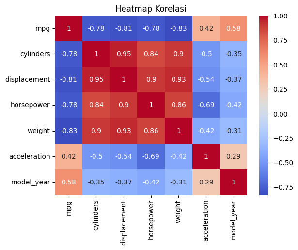

```python
corr = df.corr(numeric_only=True)
sns.heatmap(corr, annot=True, cmap="coolwarm")
plt.title("Heatmap Korelasi")
plt.show()
```

### 3. Uji Asumsi Normalitas

Uji normalitas digunakan untuk memverifikasi apakah sisa (residual) dari model menyebar normal. Uji ini penting dalam regresi. Jika nilai p > 0.05, maka residual dianggap berdistribusi normal.

```
Shapiro-Wilk Test: stat=0.982065194347652, p=8.734405247163279e-05
```

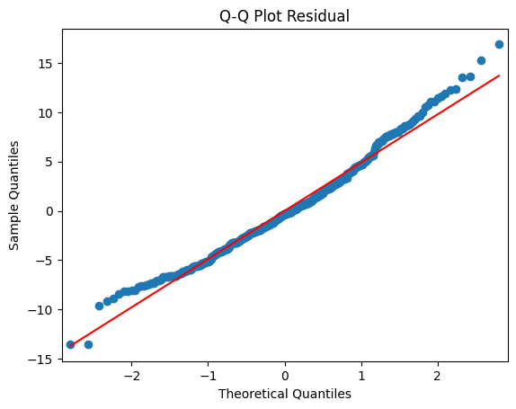

```python
residuals = model.resid

# Shapiro-Wilk test
stat, p = stats.shapiro(residuals)
print(f'Shapiro-Wilk Test: stat={stat}, p={p}')

# Q-Q plot
sm.qqplot(residuals, line='s')
plt.title("Q-Q Plot Residual")
plt.show()
```